# Wednesday, April 1st, 2026

Last class, we started to discuss salt and pepper noise.

```python
import numpy as np
import matplotlib.pyplot as plt
```

## [Project 4: Image denoising](https://jllottes.github.io/Projects/image_denoising/image_denoising.html)

We looked at loading in image files as 2D `numpy` arrays storing grayscale values. For whichever image file we want to work with, we'll read it in and convert it (if necessary) to grayscale values scaled between `0` and `1`.

```python
rgb_img = plt.imread('everton.png')[:,:,:3]    # Load in the image file and remove any transparency channel information
img = np.mean(rgb_img, axis=2)                 # Average the RGB values together for each pixel to obtain grayscale values

if img.dtype == int:                           # Check if the image contains integer data
    img = img / 255                            # If so, convert to float data
```

[figure not shown]

```python
plt.imshow(img, cmap='gray', vmin=0, vmax=1)
```

### Adding salt and pepper noise

We started too look at using the `np.random.random` function to select which pixels will be hit by salt and pepper noise.

[figure not shown]

```python
nrows, ncols = img.shape

noisy_img = img.copy()

salt_array = np.random.random((nrows, ncols))
pepper_array = np.random.random((nrows, ncols))

for row in range(nrows):
    for col in range(ncols):
        if salt_array[row, col] > .9:
            noisy_img[row, col] = 1
        if pepper_array[row, col] > .9:
            noisy_img[row, col] = 0

plt.imshow(noisy_img, cmap='gray', vmin=0, vmax=1)
```

*Note*: the implementation above gives a preference to pepper noise, since it's possible for salt pixels to be overwritten as pepper (but not the reverse). Instead, let's use a single random array, but select select different subintervals between `0` and `1` to identify salt/pepper noise:

[figure not shown]

```python
nrows, ncols = img.shape

noisy_img = img.copy()

random_array = np.random.random((nrows, ncols))

for row in range(nrows):
    for col in range(ncols):
        if random_array[row, col] > .9:
            noisy_img[row, col] = 1
        if random_array[row, col] < .1:
            noisy_img[row, col] = 0

plt.imshow(noisy_img, cmap='gray', vmin=0, vmax=1)
```

*Note*: In the example code above, we iterated through every row and column and decided for each entry whether or not to add salt and pepper noise. This is perfect case to use Boolean arrays.

*Idea*: create a `salt_mask` Boolean array containing `True` in each entry that we wish to hit with salt noise. That is, `salt_mask` should contain `True` everywhere that the `random_array` is less than, say, `0.1`.

```python
random_array = np.random.random((8,8))

bool_mask = random_array > .5

bool_mask
```

```
array([[ True, False,  True, False, False, False,  True,  True],
       [ True, False,  True,  True,  True, False,  True, False],
       [False,  True,  True, False, False,  True, False, False],
       [False, False, False,  True, False,  True, False, False],
       [False,  True,  True,  True,  True,  True,  True, False],
       [False, False,  True, False,  True,  True,  True,  True],
       [ True,  True, False, False,  True, False,  True, False],
       [False,  True,  True, False,  True,  True,  True, False]])
```

```python
noisy_img[salt_mask] = 1
noisy_img[pepp_mask] = 0
```

**Exercise.** Use the above sample code to write a function `sp_noise(img, noise)` that adds salt and pepper noise to an image. Its first argument `img` should be a 2-dimensional numpy array representing the image and the second argument `noise` should be the fraction of pixels that are to be replaced by noise (for example, with `noise = 0.05` about 5% of pixels should be noise, consisting in roughly equal parts of white and black pixels). The function should return a 2-dimensional numpy array representing the original image with noise added.

### The mean and median filters

A description of the mean filter is provided on the [project page](https://jllottes.github.io/Projects/image_denoising/image_denoising.html). Let's try to apply the mean filter.

- For right now, we will use a `3` by `3` grid centered centered at each pixel to compute the mean.
- For right now, we will ignore all pixels at the edges of the image.

For now, I will use the pre-noised image file that was downloaded from the course webpage. If you have a function `sp_noise` function, you should generate your own noisy image to use.

[figure not shown]

```python
noisy_img = np.mean(plt.imread('noisy_img.png')[:,:,:3], axis=2)
plt.imshow(noisy_img, cmap='gray', vmin=0, vmax=1)
```

Again, let's make a copy `filtered_img` of the noisy array that we will filter so that we do not modify the noisy array. This way, we will be able to compare how our filtered image looks with how the noisy image looked.

```python
filtered_img = noisy_img.copy()
```

If we are considering the pixel in the `i`th row and `j`th column (i.e. `noisy_img[i,j]`, we want a `3` by `3` slice centered on the `[i,j]`th pixel. That is, we want a slice that includes the `i-1`, `i`, and `i+1` rows and the `j-1`, `j`, and `j+1` columns.

```python
i = 50
j = 75

grid = noisy_img[i-1:i+2, j-1:j+2]

filtered_img[i,j] = np.mean(grid)
```

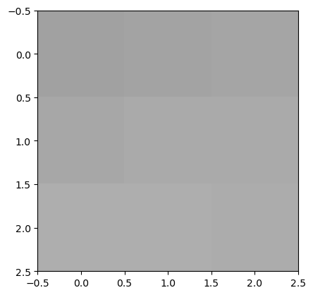

```python
plt.imshow(grid, cmap='gray', vmin=0, vmax=1)
```

Now let's go pixel by pixel and take the mean of each `3` by `3` grid to create our filtered image array. As a reminder, for now we will ignore any problematic pixels along the edge of the image.

```python
nrows, ncols = noisy_img.shape

filtered_img = noisy_img.copy()
for i in range(1,nrows-1):
    for j in range(1,ncols-1):
        grid = noisy_img[i-1:i+2, j-1:j+2]
        filtered_img[i,j] = np.mean(grid)
```

[figure not shown]

```python
plt.imshow(filtered_img, cmap='gray', vmin=0, vmax=1)
```

What about the median filter? The `np.median` function will compute the median of an array.

```python
nrows, ncols = noisy_img.shape

filtered_img = noisy_img.copy()
for i in range(1,nrows-1):
    for j in range(1,ncols-1):
        grid = noisy_img[i-1:i+2, j-1:j+2]
        filtered_img[i,j] = np.median(grid)
```

```
(np.float64(-0.5), np.float64(699.5), np.float64(494.5), np.float64(-0.5))
```

[figure not shown]

```python
plt.imshow(filtered_img, cmap='gray', vmin=0, vmax=1)
plt.axis('off')
```

**Exercise:** Use the code above to write a function `simple_mean_filter` that applies the mean filter to non-edge pixels using a `3` by `3` grid.

**Exercise:** Modify the `simple_mean_filter` function to write a `simple_median_filter` that instead applies the median filter.

**Note**: We could combine these two functions into a single `simple_filter` function that takes in a noisy image array (`noisy_img`) along with some function (`filter_func`) that will be applied to each grid.

The `filter_func` input should be a function that takes in an 2D array and returns a float (e.g. `np.mean` or `np.median`).

```python
def simple_filter(noisy_img, filter_func=np.median):
    ...
    ...
    for ...
        for ...
            grid = ...
            filtered_img[i,j] = filter_func(grid)

    return filtered_img
```

```python
filtered_img = simple_filter(noisy_img, np.mean)
```